# Ensemble_Project_Bank

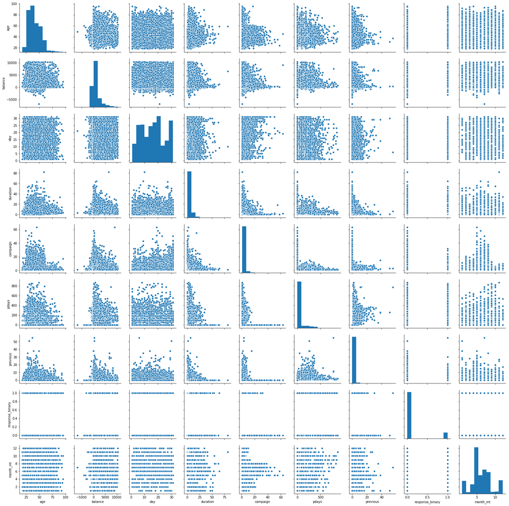

```python
# using pair plot to know the relation and distibution of each numeric variable
sns.pairplot(df6)
```

```python
# now using correlation to know the impact of each variable with one another
corr = df6.corr()
```

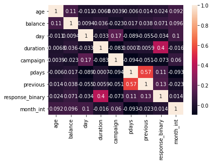

```python
# using heatmap to visualise the correlation between variables
sns.heatmap(corr, annot=True)

# As per below heatmap, duration shows good correlation with response,
# however other variables doesn't shows good correlation.
```

```python
# creating a column for age group, to analyse the subscription for that age group.
lst1 = [df6]
for column in lst1:
    column.loc[column['age'] < 30, 'age_group'] = 20
    column.loc[(column['age'] >= 30) & (column['age'] <= 39), 'age_group'] = 30
    column.loc[(column['age'] >= 40) & (column['age'] <= 49), 'age_group'] = 40
    column.loc[(column['age'] >= 50) & (column['age'] <= 59), 'age_group'] = 50
    column.loc[column['age'] >=60, 'age_group'] = 60
```

```python
df6.head()
```

|  | age | job | marital | education | default | balance | housing | loan | day | month | duration | campaign | pdays | previous | poutcome | response | response_binary | month_int | age_group |
| --- | --- | --- | --- | --- | --- | --- | --- | --- | --- | --- | --- | --- | --- | --- | --- | --- | --- | --- | --- |
| 0 | 58 | management | married | tertiary | no | 2143 | yes | no | 5 | may | 4.35 | 1 | -1 | 0 | unknown | no | 0 | 5.0 | 50.0 |
| 1 | 44 | technician | single | secondary | no | 29 | yes | no | 5 | may | 2.52 | 1 | -1 | 0 | unknown | no | 0 | 5.0 | 40.0 |
| 2 | 33 | entrepreneur | married | secondary | no | 2 | yes | yes | 5 | may | 1.27 | 1 | -1 | 0 | unknown | no | 0 | 5.0 | 30.0 |
| 3 | 47 | blue-collar | married | other | no | 1506 | yes | no | 5 | may | 1.53 | 1 | -1 | 0 | unknown | no | 0 | 5.0 | 40.0 |
| 4 | 33 | other | single | other | no | 1 | no | no | 5 | may | 3.30 | 1 | -1 | 0 | unknown | no | 0 | 5.0 | 30.0 |

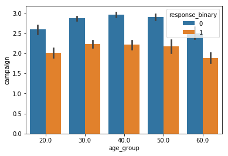

```python
# tried to know the trend of age group and campaign and response, but no significant insight.
sns.barplot(data=df6, x= 'age_group', y = 'campaign', hue='response_binary' )
```

```python
# using crosstab to know the distribution of response in age group.
pd.crosstab(df6['response'], df6['age_group'])
```

| age_group response | 20.0 | 30.0 | 40.0 | 50.0 | 60.0 |
| --- | --- | --- | --- | --- | --- |
| no | 4084 | 15240 | 10066 | 7253 | 1085 |
| yes | 852 | 1762 | 981 | 731 | 544 |

```python
# Collection data in percentage for response got for different age group.
count_age_response = pd.crosstab(df6['response'], df6['age_group']).apply(lambda  x: x/x.sum() * 100)
```

```python
# doing transpose for better view. Here we can see that 60 + and less than 30 have taken higher subscription.
count_age_response =  count_age_response.transpose()
count_age_response
```

| response age_group | no | yes |
| --- | --- | --- |
| 20.0 | 82.739060 | 17.260940 |
| 30.0 | 89.636513 | 10.363487 |
| 40.0 | 91.119761 | 8.880239 |
| 50.0 | 90.844188 | 9.155812 |
| 60.0 | 66.605279 | 33.394721 |

```python
# creating a dataframe age to calculate the % of contacted vs subscribed for different age group
age = pd.DataFrame(df6['age_group'].value_counts())
```

```python
age['% Contacted'] = age['age_group']*100/age['age_group'].sum()
age['% Subscriber'] = count_age_response['yes']
```

```python
# we can analyse that contacted % was very low in 60+ but still subscription % was very high.
age
```

|  | age_group | % Contacted | % Subscriber |
| --- | --- | --- | --- |
| 30.0 | 17002 | 39.912672 | 10.363487 |
| 40.0 | 11047 | 25.933142 | 8.880239 |
| 50.0 | 7984 | 18.742664 | 9.155812 |
| 20.0 | 4936 | 11.587398 | 17.260940 |
| 60.0 | 1629 | 3.824123 | 33.394721 |

```python
# droping age_group column.
age.drop('age_group', axis=1, inplace=True)
```

```python
# sorting age in ascending order
age['age'] = [30, 40,50,20,60]
age = age.sort_values('age', ascending=True)
```

```python
age
```

|  | % Contacted | % Subscriber | age |
| --- | --- | --- | --- |
| 20.0 | 11.587398 | 17.260940 | 20 |
| 30.0 | 39.912672 | 10.363487 | 30 |
| 40.0 | 25.933142 | 8.880239 | 40 |
| 50.0 | 18.742664 | 9.155812 | 50 |
| 60.0 | 3.824123 | 33.394721 | 60 |

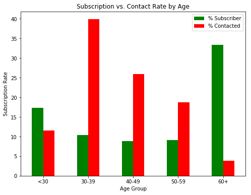

```python
# Ploting a graph to represent the sbuscription vs contacted rate in percentage according to age group.
plot_age = age[['% Subscriber','% Contacted']].plot(kind = 'bar', figsize=(8,6), color = ('green','red'))
plt.xlabel('Age Group')
plt.ylabel('Subscription Rate')
plt.xticks(np.arange(5), ('<30', '30-39', '40-49', '50-59', '60+'),rotation = 'horizontal')
plt.title('Subscription vs. Contact Rate by Age')
```

Insights: target the youngest and the oldest instead of the middle-aged

However, red vertical bars show that the bank focused its marketing efforts on the middle-aged group, which returned lower subscription rates than the younger and older groups. Thus, to make the marketing campaign more effective, the bank should target younger and older clients in the future.

```python
# Categorize balance in no, low, average and high balance category
lst2 = [df6]
for column in lst2:
    column.loc[column["balance"] <= 0,  'balance_group'] = 'no balance'
    column.loc[(column["balance"] > 0) & (column["balance"] <= 1000), 'balance_group'] = 'low balance'
    column.loc[(column["balance"] > 1000) & (column["balance"] <= 5000), 'balance_group'] = 'average balance'
    column.loc[(column["balance"] > 5000), 'balance_group'] = 'high balance'
```

```python
# % of response according to balance group calculated
count_balance_response = pd.crosstab(df6['response'],df6['balance_group']).apply(lambda x: x/x.sum() * 100)
count_balance_response = count_balance_response.transpose()
```

```python
# Calculated % contacted and % subscribed for various balance group
bal = pd.DataFrame(df6['balance_group'].value_counts())
bal['% Contacted'] = bal['balance_group']*100/bal['balance_group'].sum()
bal['% Subscription'] = count_balance_response['yes']
bal.drop('balance_group',axis = 1,inplace = True)

bal['bal'] = [1,2,0,3]
bal = bal.sort_values('bal',ascending = True)
```

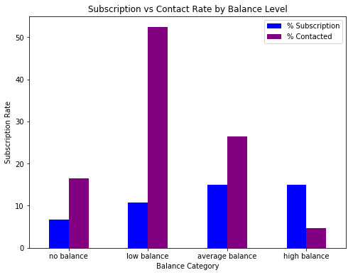

```python
# Ploting the subscription vs contact rate according to balance group
plot_balance = bal[['% Subscription','% Contacted']].plot(kind = 'bar',
                                               color = ('blue','purple'),
                                               figsize = (8,6))

plt.title('Subscription vs Contact Rate by Balance Level')
plt.ylabel('Subscription Rate')
plt.xlabel('Balance Category')
plt.xticks(rotation = 'horizontal')
```

Insights: target clients with average or high balance this bar chart indicates a positive correlation between clients’ balance levels and subscription rate. Clients with negative balances only returned a subscription rate of 6.9% while clients with average or high balances had significantly higher subscription rates, nearly 15% However, in this campaign, more than 50% of clients contacted only have a low balance level. In the future, the bank should shift its marketing focus to high-balance customers to secure more term deposits.

```python
# % response according to different job types
count_job_response = pd.crosstab(df6['response'],df6['job']).apply(lambda x: x/x.sum() * 100)
count_job_response = count_job_response.transpose()
```

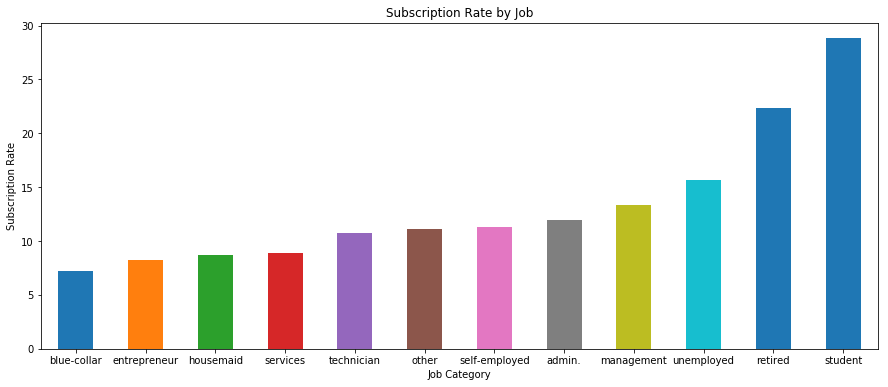

```python
# Plot the subscription by different jobs type
plot_job = count_job_response['yes'].sort_values(ascending = True).plot(kind ='bar',figsize = (15,6))

plt.title('Subscription Rate by Job')
plt.ylabel('Subscription Rate')
plt.xticks(rotation ='horizontal')
plt.xlabel('Job Category')
```

```python
# month wise response %
count_month_response = pd.crosstab(df6['response'],df6['month_int']).apply(lambda x: x/x.sum() * 100)
count_month_response = count_month_response.transpose()
```

```python
# calculating month with contacted and subscribed rate
month = pd.DataFrame(df6['month_int'].value_counts())
month['% Contacted'] = month['month_int']*100/month['month_int'].sum()
month['% Subscription'] = count_month_response['yes']
month.drop('month_int',axis = 1,inplace = True)

month['Month'] = [5,7,8,6,11,4,2,1,10,9,3,12]
month = month.sort_values('Month',ascending = True)
```

[output not shown]

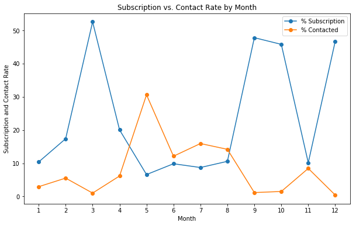

```python
# Ploting Contact vs Subscription by month using line plotting.
plot_month = month[['% Subscription','% Contacted']].plot(kind ='line', figsize = (10,6), marker = 'o')

plt.title('Subscription vs. Contact Rate by Month')
plt.ylabel('Subscription and Contact Rate')
plt.xlabel('Month')

ticks = np.arange(1,13,1)
plt.xticks(ticks)
```

Insight :- Do higher tele marketing campaign in 1st and last quarter.

Earlier campaign timing was wrong.

1 :- The bank contacted most clients between May and August. The highest contact rate is around 30%, which happened in May, while the contact rate is closer to 0 in March, September, October, and December. 2 :- However, the subscription rate showed a different trend. The highest subscription rate occurred in March, which is over 50%, and all subscription rates in September, October, and December are over 40%.

Clearly, these two lines move in different directions which strongly indicates the inappropriate timing of the bank’s marketing campaign. To improve the marketing campaign, the bank should consider initiating the telemarketing campaign in starting and ending of the year, when the subscription rate tends to be higher. however need to collect more data in future to check if this trend is consistent or not.

```python
# Marital basis response
count_marital_response = pd.crosstab(df6['response'],df6['marital']).apply(lambda x: x/x.sum() * 100)
count_marital_response = count_marital_response.transpose()
```

```python
# Single and Divorced(or widows) took the higer subscription.
count_marital_response
```

| response marital | no | yes |
| --- | --- | --- |
| divorced | 88.313008 | 11.686992 |
| married | 90.111897 | 9.888103 |
| single | 85.343384 | 14.656616 |

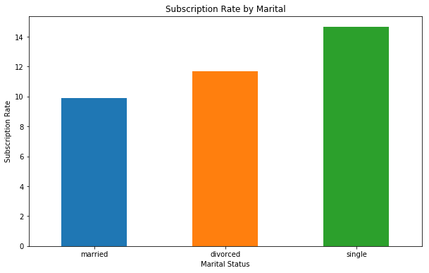

```python
# Ploting subscription rate according to Marital status.
plot_marital = count_marital_response['yes'].sort_values(ascending = True).plot(kind ='bar',figsize = (10,6))

plt.title('Subscription Rate by Marital')
plt.ylabel('Subscription Rate')
plt.xticks(rotation ='horizontal')
plt.xlabel('Marital Status')
```

```python
# Cleaning data from unwanted columns which were created to show the various plots.
df7 = df6.drop(['month_int', 'age_group', 'balance_group'], axis=1)
```

```python
df7.head()
```

|  | age | job | marital | education | default | balance | housing | loan | day | month | duration | campaign | pdays | previous | poutcome | response | response_binary |
| --- | --- | --- | --- | --- | --- | --- | --- | --- | --- | --- | --- | --- | --- | --- | --- | --- | --- |
| 0 | 58 | management | married | tertiary | no | 2143 | yes | no | 5 | may | 4.35 | 1 | -1 | 0 | unknown | no | 0 |
| 1 | 44 | technician | single | secondary | no | 29 | yes | no | 5 | may | 2.52 | 1 | -1 | 0 | unknown | no | 0 |
| 2 | 33 | entrepreneur | married | secondary | no | 2 | yes | yes | 5 | may | 1.27 | 1 | -1 | 0 | unknown | no | 0 |
| 3 | 47 | blue-collar | married | other | no | 1506 | yes | no | 5 | may | 1.53 | 1 | -1 | 0 | unknown | no | 0 |
| 4 | 33 | other | single | other | no | 1 | no | no | 5 | may | 3.30 | 1 | -1 | 0 | unknown | no | 0 |

```python
# Now saving cleaned data in file name Bank-cleaned.csv, after removing index.
df7.to_csv('Bank-cleaned.csv', index=False)
```

```python
# Load the cleaned data for classification and model building
dataset = pd.read_csv('Bank-cleaned.csv')
```

```python
dataset.head()
```

|  | age | job | marital | education | default | balance | housing | loan | day | month | duration | campaign | pdays | previous | poutcome | response | response_binary |
| --- | --- | --- | --- | --- | --- | --- | --- | --- | --- | --- | --- | --- | --- | --- | --- | --- | --- |
| 0 | 58 | management | married | tertiary | no | 2143 | yes | no | 5 | may | 4.35 | 1 | -1 | 0 | unknown | no | 0 |
| 1 | 44 | technician | single | secondary | no | 29 | yes | no | 5 | may | 2.52 | 1 | -1 | 0 | unknown | no | 0 |
| 2 | 33 | entrepreneur | married | secondary | no | 2 | yes | yes | 5 | may | 1.27 | 1 | -1 | 0 | unknown | no | 0 |
| 3 | 47 | blue-collar | married | other | no | 1506 | yes | no | 5 | may | 1.53 | 1 | -1 | 0 | unknown | no | 0 |
| 4 | 33 | other | single | other | no | 1 | no | no | 5 | may | 3.30 | 1 | -1 | 0 | unknown | no | 0 |

```python
dataset.info()
```

```
<class 'pandas.core.frame.DataFrame'>
RangeIndex: 42598 entries, 0 to 42597
Data columns (total 17 columns):
age                42598 non-null int64
job                42598 non-null object
marital            42598 non-null object
education          42598 non-null object
default            42598 non-null object
balance            42598 non-null int64
housing            42598 non-null object
loan               42598 non-null object
day                42598 non-null int64
month              42598 non-null object
duration           42598 non-null float64
campaign           42598 non-null int64
pdays              42598 non-null int64
previous           42598 non-null int64
poutcome           42598 non-null object
response           42598 non-null object
response_binary    42598 non-null int64
dtypes: float64(1), int64(7), object(9)
memory usage: 5.5+ MB
```

```python
dataset.describe().T
```

|  | count | mean | std | min | 25% | 50% | 75% | max |
| --- | --- | --- | --- | --- | --- | --- | --- | --- |
| age | 42598.0 | 40.944950 | 10.577232 | 18.0 | 33.00 | 39.0 | 48.00 | 95.00 |
| balance | 42598.0 | 1080.092633 | 1717.752898 | -6847.0 | 66.00 | 425.0 | 1342.00 | 10443.00 |
| day | 42598.0 | 15.862552 | 8.328469 | 1.0 | 8.00 | 16.0 | 21.00 | 31.00 |
| duration | 42598.0 | 4.308568 | 4.297547 | 0.1 | 1.72 | 3.0 | 5.32 | 81.97 |
| campaign | 42598.0 | 2.778112 | 3.138577 | 1.0 | 1.00 | 2.0 | 3.00 | 63.00 |
| pdays | 42598.0 | 32.163200 | 90.594777 | -1.0 | -1.00 | -1.0 | -1.00 | 871.00 |
| previous | 42598.0 | 0.434527 | 1.562698 | 0.0 | 0.00 | 0.0 | 0.00 | 55.00 |
| response_binary | 42598.0 | 0.114325 | 0.318209 | 0.0 | 0.00 | 0.0 | 0.00 | 1.00 |

```python
# Still we can see that there are outliers in duration, campaign, pdays and previous. So let's use zscore.
# And remove outliers.

dff2 = pd.read_csv('Bank-cleaned.csv')
```

```python
dff2['pdays'] = zscore(dff2['pdays'])
condition2 = (dff2['pdays'] > 3) | (dff2['pdays'] < -3)
dff3 = dff2.drop(dff2[condition2].index,axis=0, inplace=False)
```

```python
dff3['previous'] = zscore(dff3['previous'])
condition4 = (dff3['previous'] > 3) | (dff3['previous'] < -3)
dff4 = dff3.drop(dff3[condition4].index,axis=0, inplace=False)
```

```python
dff4['campaign'] = zscore(dff4['campaign'])
condition5 = (dff4['campaign'] > 3) | (dff4['campaign'] < -3)
dff5 = dff4.drop(dff4[condition5].index,axis=0, inplace=False)
```

```python
dff5['duration'] = zscore(dff5['duration'])
condition6 = (dff5['duration'] > 3) | (dff5['duration'] < -3)
dff6 = dff5.drop(dff5[condition6].index,axis=0, inplace=False)
```

```python
dff6.head()
```

|  | age | job | marital | education | default | balance | housing | loan | day | month | duration | campaign | pdays | previous | poutcome | response | response_binary |
| --- | --- | --- | --- | --- | --- | --- | --- | --- | --- | --- | --- | --- | --- | --- | --- | --- | --- |
| 0 | 58 | management | married | tertiary | no | 2143 | yes | no | 5 | may | 0.001459 | -0.567676 | -0.366065 | -0.244374 | unknown | no | 0 |
| 1 | 44 | technician | single | secondary | no | 29 | yes | no | 5 | may | -0.421995 | -0.567676 | -0.366065 | -0.244374 | unknown | no | 0 |
| 2 | 33 | entrepreneur | married | secondary | no | 2 | yes | yes | 5 | may | -0.711239 | -0.567676 | -0.366065 | -0.244374 | unknown | no | 0 |
| 3 | 47 | blue-collar | married | other | no | 1506 | yes | no | 5 | may | -0.651076 | -0.567676 | -0.366065 | -0.244374 | unknown | no | 0 |
| 4 | 33 | other | single | other | no | 1 | no | no | 5 | may | -0.241506 | -0.567676 | -0.366065 | -0.244374 | unknown | no | 0 |

```python
dff6.info()
```

```
<class 'pandas.core.frame.DataFrame'>
Int64Index: 38353 entries, 0 to 42597
Data columns (total 17 columns):
age                38353 non-null int64
job                38353 non-null object
marital            38353 non-null object
education          38353 non-null object
default            38353 non-null object
balance            38353 non-null int64
housing            38353 non-null object
loan               38353 non-null object
day                38353 non-null int64
month              38353 non-null object
duration           38353 non-null float64
campaign           38353 non-null float64
pdays              38353 non-null float64
previous           38353 non-null float64
poutcome           38353 non-null object
response           38353 non-null object
response_binary    38353 non-null int64
dtypes: float64(4), int64(4), object(9)
memory usage: 5.3+ MB
```

```
array([[<matplotlib.axes._subplots.AxesSubplot object at 0x000001D232A22390>,
      dtype=object)
```

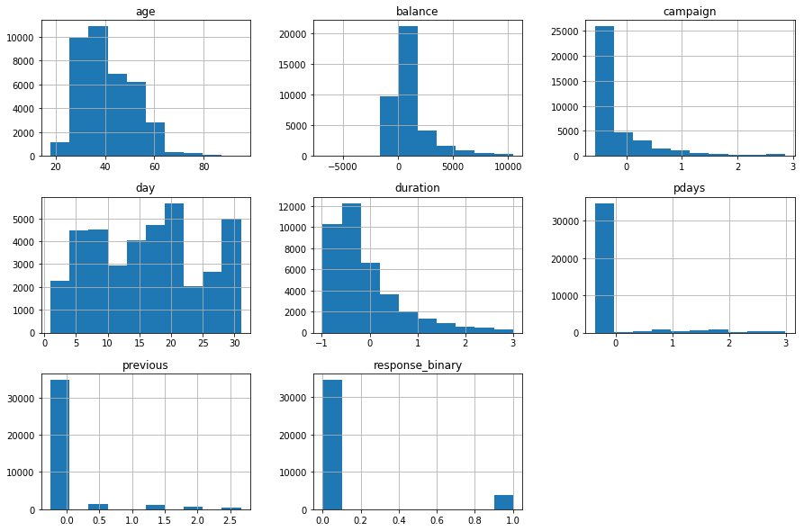

```python
# using histogram to check to frequency and distribution of the data.
dff6.hist(figsize = (15,10))
```

[output not shown]

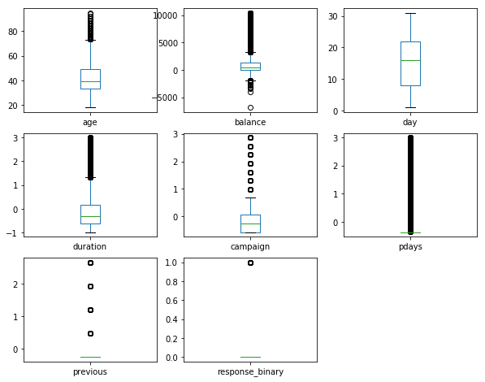

```python
# Box plot to check outlier status
dff6.plot(kind= 'box' , subplots=True, layout=(3,3), sharex=False, sharey=False, figsize=(10,8))
```

```python
# Taking all the value of dff6 in dataset1

dataset1 = dff6
```

```python
dataset1.info()
```

```
<class 'pandas.core.frame.DataFrame'>
Int64Index: 38353 entries, 0 to 42597
Data columns (total 17 columns):
age                38353 non-null int64
job                38353 non-null object
marital            38353 non-null object
education          38353 non-null object
default            38353 non-null object
balance            38353 non-null int64
housing            38353 non-null object
loan               38353 non-null object
day                38353 non-null int64
month              38353 non-null object
duration           38353 non-null float64
campaign           38353 non-null float64
pdays              38353 non-null float64
previous           38353 non-null float64
poutcome           38353 non-null object
response           38353 non-null object
response_binary    38353 non-null int64
dtypes: float64(4), int64(4), object(9)
memory usage: 5.3+ MB
```

```python
# Since many variable are of data type object which is a string data type. So let's transform them in categorical.
# For categorical variables transform them in dummies and for binary replacing yes and no with 1 and 0.

dataset2 = pd.get_dummies(dataset1, columns = ['job'])
dataset2 = pd.get_dummies(dataset2, columns = ['education'])
dataset2 = pd.get_dummies(dataset2, columns = ['marital'])
dataset2 = pd.get_dummies(dataset2, columns = ['poutcome'])
dataset2 = pd.get_dummies(dataset2, columns = ['month'])
dataset2 = pd.get_dummies(dataset2, columns = ['day'])
dataset2['housing'] = dataset2['housing'].map({'yes': 1, 'no': 0})
dataset2['default'] = dataset2['default'].map({'yes': 1, 'no': 0})
dataset2['loan'] = dataset2['loan'].map({'yes': 1, 'no': 0})
```

```python
# Droping response column as reponse_binary already created.
dataset2.drop('response', axis=1, inplace=True)
```

```python
dataset2.head()
# Now we have 75 columns and non of them are string variable.
```

|  | age | default | balance | housing | loan | duration | campaign | pdays | previous | response_binary | ... | day_22 | day_23 | day_24 | day_25 | day_26 | day_27 | day_28 | day_29 | day_30 | day_31 |
| --- | --- | --- | --- | --- | --- | --- | --- | --- | --- | --- | --- | --- | --- | --- | --- | --- | --- | --- | --- | --- | --- |
| 0 | 58 | 0 | 2143 | 1 | 0 | 0.001459 | -0.567676 | -0.366065 | -0.244374 | 0 | ... | 0 | 0 | 0 | 0 | 0 | 0 | 0 | 0 | 0 | 0 |
| 1 | 44 | 0 | 29 | 1 | 0 | -0.421995 | -0.567676 | -0.366065 | -0.244374 | 0 | ... | 0 | 0 | 0 | 0 | 0 | 0 | 0 | 0 | 0 | 0 |
| 2 | 33 | 0 | 2 | 1 | 1 | -0.711239 | -0.567676 | -0.366065 | -0.244374 | 0 | ... | 0 | 0 | 0 | 0 | 0 | 0 | 0 | 0 | 0 | 0 |
| 3 | 47 | 0 | 1506 | 1 | 0 | -0.651076 | -0.567676 | -0.366065 | -0.244374 | 0 | ... | 0 | 0 | 0 | 0 | 0 | 0 | 0 | 0 | 0 | 0 |
| 4 | 33 | 0 | 1 | 0 | 0 | -0.241506 | -0.567676 | -0.366065 | -0.244374 | 0 | ... | 0 | 0 | 0 | 0 | 0 | 0 | 0 | 0 | 0 | 0 |

5 rows × 75 columns

```python
# Since response_binary is our target column, let's move this column to front of the dataset make it first column
# for easy observation.

first = dataset2['response_binary']
dataset2.drop(labels='response_binary', axis=1, inplace=True)
```

```python
dataset2.insert(0, 'response_binary', first)
dataset2.head()
```

|  | response_binary | age | default | balance | housing | loan | duration | campaign | pdays | previous | ... | day_22 | day_23 | day_24 | day_25 | day_26 | day_27 | day_28 | day_29 | day_30 | day_31 |
| --- | --- | --- | --- | --- | --- | --- | --- | --- | --- | --- | --- | --- | --- | --- | --- | --- | --- | --- | --- | --- | --- |
| 0 | 0 | 58 | 0 | 2143 | 1 | 0 | 0.001459 | -0.567676 | -0.366065 | -0.244374 | ... | 0 | 0 | 0 | 0 | 0 | 0 | 0 | 0 | 0 | 0 |
| 1 | 0 | 44 | 0 | 29 | 1 | 0 | -0.421995 | -0.567676 | -0.366065 | -0.244374 | ... | 0 | 0 | 0 | 0 | 0 | 0 | 0 | 0 | 0 | 0 |
| 2 | 0 | 33 | 0 | 2 | 1 | 1 | -0.711239 | -0.567676 | -0.366065 | -0.244374 | ... | 0 | 0 | 0 | 0 | 0 | 0 | 0 | 0 | 0 | 0 |
| 3 | 0 | 47 | 0 | 1506 | 1 | 0 | -0.651076 | -0.567676 | -0.366065 | -0.244374 | ... | 0 | 0 | 0 | 0 | 0 | 0 | 0 | 0 | 0 | 0 |
| 4 | 0 | 33 | 0 | 1 | 0 | 0 | -0.241506 | -0.567676 | -0.366065 | -0.244374 | ... | 0 | 0 | 0 | 0 | 0 | 0 | 0 | 0 | 0 | 0 |

5 rows × 75 columns

```python
# Now let's do the Feature Selection and create X and y.
X = dataset2.iloc[:, 1:76].values
y = dataset2.iloc[:, 0].values
```

```python
# Splitting the dataset into the Training set and Test set
from sklearn.model_selection import train_test_split
X_train, X_test, y_train, y_test = train_test_split(X, y, test_size = 0.3, random_state = 0)
```

```python
# Scaling of independent Variables

from sklearn.preprocessing import StandardScaler
```

```python
sc = StandardScaler()
```

```python
X_train = sc.fit_transform(X_train)
X_test = sc.fit_transform(X_test)
```

```python
## Build Classifier 1  Naive Bayes
from sklearn import metrics
from sklearn.naive_bayes import GaussianNB, MultinomialNB
classifier_NB = GaussianNB()
classifier_NB.fit(X_train,y_train)
y_pred_NB = classifier_NB.predict(X_test)
metrics.accuracy_score(y_pred_NB,y_test)
```

```
0.8457326612202329
```

```python
print(metrics.confusion_matrix(y_test, y_pred_NB))
```

```
[[9178 1175]
 [ 600  553]]
```

```python
def draw_cm_NB( y_test, y_pred_NB ):
    cm_NB = metrics.confusion_matrix( y_test, y_pred_NB )
    sns.heatmap(cm_NB, annot=True,  fmt='.2f', xticklabels = ["No", "Yes"] , yticklabels = ["No", "Yes"] )
    plt.ylabel('True label')
    plt.xlabel('Predicted label')
    plt.show()
```

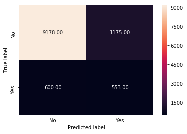

```python
draw_cm_NB( y_test, y_pred_NB  )
```

```python
## Build Classifier 2  Random Forest
from sklearn.ensemble import RandomForestClassifier
classifier_RF = RandomForestClassifier()
classifier_RF.fit(X_train,y_train)
y_pred_RF = classifier_RF.predict(X_test)
metrics.accuracy_score(y_pred_RF,y_test)
```

```
0.9111767773335651
```

```python
print(metrics.confusion_matrix(y_test, y_pred_RF))
```

```
[[10191   162]
 [  860   293]]
```

```python
## Build Classifier 2.1 Random Forest
from sklearn.ensemble import RandomForestClassifier
classifier_RF = RandomForestClassifier(n_estimators = 100, criterion = 'gini', random_state = 0,n_jobs= 3)
classifier_RF.fit(X_train,y_train)
y_pred_RF = classifier_RF.predict(X_test)
metrics.accuracy_score(y_pred_RF,y_test)
```

```
0.9147401355814357
```

```python
## Build Classifier 2.2 Random Forest
from sklearn.ensemble import RandomForestClassifier
classifier_RF = RandomForestClassifier(n_estimators = 500, criterion = 'gini', random_state = 0,n_jobs= 3)
classifier_RF.fit(X_train,y_train)
y_pred_RF = classifier_RF.predict(X_test)
metrics.accuracy_score(y_pred_RF,y_test)
```

```
0.9148270467582131
```

```python
print(metrics.confusion_matrix(y_test, y_pred_RF))
```

```
[[10198   155]
 [  825   328]]
```

```python
## Build Classifier 2.3 Random Forest
from sklearn.ensemble import RandomForestClassifier
classifier_RF = RandomForestClassifier(n_estimators = 100, criterion = 'entropy', random_state = 12345,n_jobs= 4, max_depth=40)
classifier_RF.fit(X_train,y_train)
y_pred_RF = classifier_RF.predict(X_test)
metrics.accuracy_score(y_pred_RF,y_test)
```

```
0.9135233791065531
```

```python
## Build Classifier 3  GradientBoosting
from sklearn.ensemble import GradientBoostingClassifier
classifier_GBC = GradientBoostingClassifier()
classifier_GBC.fit(X_train,y_train)
y_pred_GBC = classifier_GBC.predict(X_test)
metrics.accuracy_score(y_pred_GBC,y_test)
```

```
0.9151746914653225
```

```python
## Build Classifier 3.1  GradientBoosting
from sklearn.ensemble import GradientBoostingClassifier
classifier_GBC = GradientBoostingClassifier(loss='deviance', random_state= 1, learning_rate=0.2, n_estimators=150, subsample=1.0, criterion='friedman_mse',)
classifier_GBC.fit(X_train,y_train)
y_pred_GBC = classifier_GBC.predict(X_test)
metrics.accuracy_score(y_pred_GBC,y_test)
```

```
0.9165652702937598
```

```python
print(metrics.confusion_matrix(y_test, y_pred_GBC))
```

```
[[10126   227]
 [  733   420]]
```

```python
def draw_cm_GBC( y_test, y_pred_GBC ):
    cm_GBC = metrics.confusion_matrix( y_test, y_pred_GBC )
    sns.heatmap(cm_GBC, annot=True,  fmt='.2f', xticklabels = ["No", "Yes"] , yticklabels = ["No", "Yes"] )
    plt.ylabel('True label')
    plt.xlabel('Predicted label')
    plt.show()
```

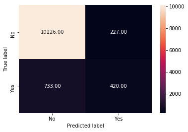

```python
draw_cm_GBC( y_test, y_pred_GBC  )
```

```python
# Classification Report
from sklearn.metrics import classification_report
print(classification_report(y_test, y_pred_GBC))
```

```
              precision    recall  f1-score   support

           0       0.93      0.98      0.95     10353
           1       0.65      0.36      0.47      1153

   micro avg       0.92      0.92      0.92     11506
   macro avg       0.79      0.67      0.71     11506
weighted avg       0.90      0.92      0.91     11506
```

```python
from sklearn.ensemble import AdaBoostClassifier
from sklearn.tree import DecisionTreeClassifier
```

```python
# Classifier Boosting - 4
dt = DecisionTreeClassifier()
classifier_ADB = AdaBoostClassifier(n_estimators=100, base_estimator=dt,learning_rate=1)
classifier_ADB.fit(X_train,y_train)
y_pred_ADB = classifier_ADB.predict(X_test)
metrics.accuracy_score(y_pred_RF,y_test)
```

```
0.9135233791065531
```

```python
# Classifier Boosting - 4.1
classifier_ADB = AdaBoostClassifier(n_estimators=100, base_estimator=classifier_NB,learning_rate=1)
classifier_ADB.fit(X_train,y_train)
y_pred_ADB = classifier_ADB.predict(X_test)
metrics.accuracy_score(y_pred_RF,y_test)
```

```
0.9135233791065531
```

```python
# Classifier Decision Tree 5
classifier_DT = DecisionTreeClassifier()
classifier_DT.fit(X_train, y_train)
y_pred_DT = classifier_DT.predict(X_test)
metrics.accuracy_score(y_pred_DT,y_test)
```

```
0.887450026073353
```

```python
# Classifier Decision Tree 5.1
classifier_DT = DecisionTreeClassifier(criterion='entropy', max_depth= 6, random_state= 1)
classifier_DT.fit(X_train, y_train)
y_pred_DT = classifier_DT.predict(X_test)
metrics.accuracy_score(y_pred_DT,y_test)
```

```
0.9088301755605771
```

```python
# Classifier Bagging 6
from sklearn.ensemble import BaggingClassifier
classifier_BAG = BaggingClassifier()
classifier_BAG.fit(X_train, y_train)
y_pred_BAG = classifier_BAG.predict(X_test)
metrics.accuracy_score(y_pred_BAG,y_test)
```

```
0.9103076655657918
```

```python
# Classifier Bagging 6.1 using Decision Tree
from sklearn.ensemble import BaggingClassifier
classifier_BAG = BaggingClassifier(base_estimator=classifier_DT, n_estimators=50, random_state=1)
classifier_BAG.fit(X_train, y_train)
y_pred_BAG = classifier_BAG.predict(X_test)
metrics.accuracy_score(y_pred_BAG,y_test)
```

```
0.9104814879193465
```

```python
# Classifier Bagging 6.1 using Naive Bayse
from sklearn.ensemble import BaggingClassifier
classifier_BAG = BaggingClassifier(base_estimator=classifier_NB, n_estimators=50, random_state=1)
classifier_BAG.fit(X_train, y_train)
y_pred_BAG = classifier_BAG.predict(X_test)
metrics.accuracy_score(y_pred_BAG,y_test)
```

```
0.8478185294628889
```

```python
# Now let's try Stacking

from vecstack import stacking
```

```python
from sklearn.neighbors import KNeighborsClassifier
from sklearn.linear_model import LogisticRegression
from sklearn.metrics import accuracy_score
```

```python
models = [
    KNeighborsClassifier(n_neighbors=5,
                        n_jobs=-1),

    RandomForestClassifier(random_state=0, n_jobs=-3,
                           n_estimators=500, criterion='gini'),

    LogisticRegression(random_state=0, n_jobs=-1),

    GradientBoostingClassifier(loss='deviance', random_state= 0, learning_rate=0.2, n_estimators=150,
                               subsample=1.0, criterion='friedman_mse',)

]
```

```python
S_train, S_test = stacking(models,
                           X_train, y_train, X_test,
                           regression=False,

                           mode='oof_pred_bag',

                           needs_proba=False,

                           save_dir=None,

                           metric=accuracy_score,

                           n_folds=4,

                           stratified=True,

                           shuffle=True,

                           random_state=0,

                           verbose=2)
```

```
task:         [classification]
n_classes:    [2]
metric:       [accuracy_score]
mode:         [oof_pred_bag]
n_models:     [4]

model  0:     [KNeighborsClassifier]
    fold  0:  [0.90718117]
    fold  1:  [0.90673421]
    fold  2:  [0.90852205]
    fold  3:  [0.90701833]
    ----
    MEAN:     [0.90736394] + [0.00068750]
    FULL:     [0.90736395]

model  1:     [RandomForestClassifier]
    fold  0:  [0.91343862]
    fold  1:  [0.91358760]
    fold  2:  [0.91954708]
    fold  3:  [0.91446878]
    ----
    MEAN:     [0.91526052] + [0.00250596]
    FULL:     [0.91526055]

model  2:     [LogisticRegression]
```

```
    fold  0:  [0.91105483]
```

```
    fold  1:  [0.91179976]
```

```
    fold  2:  [0.91477950]
```

```
    fold  3:  [0.90835941]
    ----
    MEAN:     [0.91149837] + [0.00228618]
    FULL:     [0.91149849]

model  3:     [GradientBoostingClassifier]
    fold  0:  [0.91314064]
    fold  1:  [0.91328963]
    fold  2:  [0.91954708]
    fold  3:  [0.91551185]
    ----
    MEAN:     [0.91537230] + [0.00258680]
    FULL:     [0.91537229]
```

```python
# Creating final model and making final Prediction
model = GradientBoostingClassifier(loss='deviance', random_state= 0, learning_rate=0.2, n_estimators=150,
                               subsample=1.0, criterion='friedman_mse',)
model = model.fit(S_train, y_train)
y_pred = model.predict(S_test)
print('Prediction score: [%.8f]' % accuracy_score(y_test, y_pred))
```

```
Prediction score: [0.91439249]
```

```python
# Plotting final confusion matrix
def draw_cmf_GBC( y_test, y_pred ):
    cmf_GBC = metrics.confusion_matrix( y_test, y_pred )
    sns.heatmap(cmf_GBC, annot=True,  fmt='.2f', xticklabels = ["No", "Yes"] , yticklabels = ["No", "Yes"] )
    plt.ylabel('True label')
    plt.xlabel('Predicted label')
    plt.show()
```